# st-project

Brian Crist

4/29/2021

*This analysis is adapted from a project I did at Boston College in the fall semester of 2020 for the course “Software Tools for Data Analysis” as part of the M.S. in Applied Economics program.*

# Introduction

In this report I utilize data from two different sources, the American Community Survey (ACS) and the Iowa Department of Commerce (IDC) to analyze data regarding liquor sales, race, and income in Iowa. The data from both sources is provided across three geographic levels (city, county, zipcode). For a general overview I aggregate the overall racial diversity as an index and use this to understand general trends with regard to the racial makeup of an area. One finding is that areas classified as more diverse have a higher average amount spent per liter of liquor than less diverse locations.

```r
# clean environment/console
rm(list = ls())
cat("\f")
```

```r
# load packages
packages <- c("ggplot2"
              , "ggrepel"
              , "knitr"
              , "RColorBrewer"
              , "dplyr"
              , "lemon"
              , "scales"
              )

for (i in 1:length(packages)) {
  if (!packages[i] %in% rownames(installed.packages())) {
    install.packages(packages[i])
  }
  library(packages[i], character.only = TRUE)
}
rm(packages)
# set working directory to load data
setwd("/home/brian/documents/classes/software.tools/final")
# load data
acs.cities <- read.csv("project.acs.cities.csv")
acs.counties <- read.csv("project.acs.counties.csv")
acs.zipcodes <- read.csv("project.acs.zipcodes.csv")
sales.cities <- read.csv("project.sales.cities.csv")
sales.counties <- read.csv("project.sales.counties.csv")
sales.zipcodes <- read.csv("project.sales.zipcodes.csv")

# delete unneeded columns
acs.cities[, c("high.school", "bachelor", "unemployment")] <- NULL
acs.counties[, c("high.school", "bachelor", "unemployment")] <- NULL
acs.zipcodes[, c("high.school", "bachelor", "unemployment")] <- NULL
```

# Data Summary

## IDC Data

The IDC data is divided across three separate files, one at each geographic level. Each file lists the total sales in dollars and volume for each of ten liquor categories for every location. The data has been aggregated and summarized in the tables below.

### Overview

```r
# IDC descriptive statistics

city.dol.sum <- sum(sales.cities$sale.dollars)
city.vol.sum <- sum(sales.cities$sale.volume)
city.count.sum <- length(unique(sales.cities$city))

county.dol.sum <- sum(sales.counties$sale.dollars)
county.vol.sum <- sum(sales.counties$sale.volume)
county.count.sum <- length(unique(sales.counties$county))

zip.dol.sum <- sum(sales.zipcodes$sale.dollars)
zip.vol.sum <- sum(sales.zipcodes$sale.volume)
zip.count.sum <- length(unique(sales.zipcodes$zipcode))

sales.all <- as.data.frame(cbind(c(city.dol.sum
                                   , city.vol.sum
                                   , city.count.sum)
                                 , c(county.dol.sum
                                     , county.vol.sum
                                     , county.count.sum)
                                 , c(zip.dol.sum
                                     , zip.vol.sum
                                     , zip.count.sum)
                                 )
                           )

colnames(sales.all) <- c("City", "County", "Zipcode")
rownames(sales.all) <- c("Sum of sales, dollars"
                         , "Sum of sales, liters"
                         , "Unique locations")

kable(sales.all
      , format.args = list(big.mark = ",")
      , caption = "Iowa Liquor Sales")
```

Iowa Liquor Sales

|  | City | County | Zipcode |
| --- | --- | --- | --- |
| Sum of sales, dollars | 263,949,815 | 263,949,798 | 263,949,807 |
| Sum of sales, liters | 18,123,050 | 18,123,026 | 18,123,057 |
| Unique locations | 389 | 99 | 429 |

### Cities

```r
# Liquor Cities
# sales in dollars
sales.cities.stats.dol <- as.data.frame(matrix(ncol = 7
                                           , nrow = 10))
colnames(sales.cities.stats.dol) <- c("variable", "n", "min"
                                      , "mean", "median", "max"
                                      , "isNA")
labs <- sales.cities$category[1:10]
sales.cities.stats.dol$variable <- labs
for (i in 1:length(labs)){
  sales.cities.stats.dol$n[i] <- nrow(sales.cities) - sum(as.numeric(is.na(sales.cities[sales.cities$category == sales.cities$category[i], "sale.dollars"])))
  sales.cities.stats.dol$min[i] <- min(na.omit(sales.cities[sales.cities$category == sales.cities$category[i], "sale.dollars"]))
  sales.cities.stats.dol$mean[i] <- round(mean(na.omit(sales.cities[sales.cities$category == sales.cities$category[i],"sale.dollars"])))
  sales.cities.stats.dol$median[i] <- round(median(na.omit(sales.cities[sales.cities$category == sales.cities$category[i],"sale.dollars"])))
  sales.cities.stats.dol$max[i] <- max(na.omit(sales.cities[sales.cities$category == sales.cities$category[i],"sale.dollars"]))
  sales.cities.stats.dol$isNA[i] <- sum(as.numeric(is.na(sales.cities[sales.cities$category == sales.cities$category[i],"sale.dollars"])))
}
kable(sales.cities.stats.dol
      , format.args = list(big.mark = ",")
      , caption = "Iowa Cities Liquor Sales/$")
```

Iowa Cities Liquor Sales/$

| variable | n | min | mean | median | max | isNA |
| --- | --- | --- | --- | --- | --- | --- |
| Misc | 3,753 | 28 | 60,904 | 5,253 | 3,397,260 | 0 |
| Whisky | 3,753 | 57 | 236,912 | 35,282 | 12,225,234 | 0 |
| Rum | 3,753 | 28 | 91,695 | 13,746 | 4,013,435 | 0 |
| Brandy | 3,753 | 3 | 27,904 | 2,028 | 2,177,548 | 0 |
| Amaretto | 3,753 | 1 | 3,015 | 362 | 120,986 | 0 |
| Vodka | 3,753 | 9 | 161,967 | 17,834 | 9,907,123 | 0 |
| Gin | 3,753 | 1 | 19,344 | 1,122 | 1,220,280 | 0 |
| Schnapps | 3,753 | 20 | 30,609 | 4,505 | 1,409,948 | 0 |
| Tequila | 3,753 | 9 | 44,437 | 2,812 | 3,428,570 | 0 |
| Distilled Spirits | 3,753 | 3 | 5,263 | 536 | 180,690 | 0 |

```r
# sales in volume
sales.cities.stats.vol <- as.data.frame(matrix(ncol = 7
                                           , nrow = 10))
colnames(sales.cities.stats.vol) <- c("variable", "n", "min", "mean", "median", "max", "isNA")
labs <- sales.cities$category[1:10]
sales.cities.stats.vol$variable <- labs
for (i in 1:length(labs)){
  sales.cities.stats.vol$n[i] <- nrow(sales.cities) - sum(as.numeric(is.na(sales.cities[sales.cities$category == sales.cities$category[i], "sale.volume"])))
  sales.cities.stats.vol$min[i] <- min(na.omit(sales.cities[sales.cities$category == sales.cities$category[i], "sale.volume"]))
  sales.cities.stats.vol$mean[i] <- round(mean(na.omit(sales.cities[sales.cities$category == sales.cities$category[i],"sale.volume"])))
  sales.cities.stats.vol$median[i] <- round(median(na.omit(sales.cities[sales.cities$category == sales.cities$category[i],"sale.volume"])))
  sales.cities.stats.vol$max[i] <- max(na.omit(sales.cities[sales.cities$category == sales.cities$category[i],"sale.volume"]))
  sales.cities.stats.vol$isNA[i] <- sum(as.numeric(is.na(sales.cities[sales.cities$category == sales.cities$category[i],"sale.volume"])))
}
kable(sales.cities.stats.vol
      , format.args = list(big.mark = ",")
      , caption = "Iowa Cities Liquor Sales/volume (L)")
```

Iowa Cities Liquor Sales/volume (L)

| variable | n | min | mean | median | max | isNA |
| --- | --- | --- | --- | --- | --- | --- |
| Misc | 3,753 | 0 | 3,559 | 317 | 187,528 | 0 |
| Whisky | 3,753 | 4 | 14,340 | 2,531 | 653,282 | 0 |
| Rum | 3,753 | 3 | 6,538 | 942 | 286,968 | 0 |
| Brandy | 3,753 | 0 | 1,427 | 169 | 89,852 | 0 |
| Amaretto | 3,753 | 0 | 291 | 42 | 11,081 | 0 |
| Vodka | 3,753 | 0 | 13,973 | 1,802 | 771,338 | 0 |
| Gin | 3,753 | 0 | 1,431 | 104 | 86,697 | 0 |
| Schnapps | 3,753 | 2 | 2,221 | 372 | 101,552 | 0 |
| Tequila | 3,753 | 0 | 2,607 | 178 | 186,907 | 0 |
| Distilled Spirits | 3,753 | 0 | 470 | 25 | 21,519 | 0 |

### Counties

```r
# Liquor Counties
# sales in dollars
sales.counties.stats.dol <- as.data.frame(matrix(ncol = 7
                                             , nrow = 10))
colnames(sales.counties.stats.dol) <- c("variable", "n", "min", "mean", "median", "max", "isNA")
labs <- sales.counties$category[1:10]
sales.counties.stats.dol$variable <- labs
for (i in 1:length(labs)){
  sales.counties.stats.dol$n[i] <- nrow(sales.counties) - sum(as.numeric(is.na(sales.counties[sales.counties$category == sales.counties$category[i], "sale.dollars"])))
  sales.counties.stats.dol$min[i] <- min(na.omit(sales.counties[sales.counties$category == sales.counties$category[i], "sale.dollars"]))
  sales.counties.stats.dol$mean[i] <- round(mean(na.omit(sales.counties[sales.counties$category == sales.counties$category[i],"sale.dollars"])))
  sales.counties.stats.dol$median[i] <- round(median(na.omit(sales.counties[sales.counties$category == sales.counties$category[i],"sale.dollars"])))
  sales.counties.stats.dol$max[i] <- max(na.omit(sales.counties[sales.counties$category == sales.counties$category[i],"sale.dollars"]))
  sales.counties.stats.dol$isNA[i] <- sum(as.numeric(is.na(sales.counties[sales.counties$category == sales.counties$category[i],"sale.dollars"])))
}
kable(sales.counties.stats.dol
      , format.args = list(big.mark = ",")
      , caption = "Iowa Counties Liquor Sales/$")
```

Iowa Counties Liquor Sales/$

| variable | n | min | mean | median | max | isNA |
| --- | --- | --- | --- | --- | --- | --- |
| Misc | 990 | 1,241 | 238,081 | 69,287 | 5,464,019 | 0 |
| Whisky | 990 | 11,133 | 930,897 | 317,777 | 20,496,221 | 0 |
| Rum | 990 | 5,883 | 359,371 | 132,003 | 6,905,429 | 0 |
| Brandy | 990 | 133 | 108,235 | 18,534 | 2,661,985 | 0 |
| Amaretto | 990 | 24 | 10,353 | 3,298 | 211,535 | 0 |
| Vodka | 990 | 4,383 | 634,782 | 158,147 | 16,434,338 | 0 |
| Gin | 990 | 164 | 75,030 | 13,987 | 1,997,056 | 0 |
| Schnapps | 990 | 652 | 119,033 | 43,782 | 1,859,058 | 0 |
| Tequila | 990 | 679 | 173,260 | 37,510 | 4,764,464 | 0 |
| Distilled Spirits | 990 | 275 | 17,118 | 3,942 | 353,111 | 0 |

```r
# sales in volume
sales.counties.stats.vol <- as.data.frame(matrix(ncol = 7
                                             , nrow = 10))
colnames(sales.counties.stats.vol) <- c("variable", "n", "min", "mean", "median", "max", "isNA")
labs <- sales.counties$category[1:10]
sales.counties.stats.vol$variable <- labs
for (i in 1:length(labs)){
  sales.counties.stats.vol$n[i] <- nrow(sales.counties) - sum(as.numeric(is.na(sales.counties[sales.counties$category == sales.counties$category[i], "sale.volume"])))
  sales.counties.stats.vol$min[i] <- min(na.omit(sales.counties[sales.counties$category == sales.counties$category[i], "sale.volume"]))
  sales.counties.stats.vol$mean[i] <- round(mean(na.omit(sales.counties[sales.counties$category == sales.counties$category[i],"sale.volume"])))
  sales.counties.stats.vol$median[i] <- round(median(na.omit(sales.counties[sales.counties$category == sales.counties$category[i],"sale.volume"])))
  sales.counties.stats.vol$max[i] <- max(na.omit(sales.counties[sales.counties$category == sales.counties$category[i],"sale.volume"]))
  sales.counties.stats.vol$isNA[i] <- sum(as.numeric(is.na(sales.counties[sales.counties$category == sales.counties$category[i],"sale.volume"])))
}
kable(sales.counties.stats.vol
      , format.args = list(big.mark = ",")
      , caption = "Iowa Counties Liquor Sales/volume (L)")
```

Iowa Counties Liquor Sales/volume (L)

| variable | n | min | mean | median | max | isNA |
| --- | --- | --- | --- | --- | --- | --- |
| Misc | 990 | 51 | 13,914 | 4,118 | 302,997 | 0 |
| Whisky | 990 | 670 | 56,347 | 23,201 | 1,084,197 | 0 |
| Rum | 990 | 317 | 25,623 | 9,091 | 487,875 | 0 |
| Brandy | 990 | 8 | 5,537 | 1,594 | 114,798 | 0 |
| Amaretto | 990 | 4 | 1,000 | 360 | 17,655 | 0 |
| Vodka | 990 | 425 | 54,764 | 15,919 | 1,288,859 | 0 |
| Gin | 990 | 10 | 5,549 | 1,313 | 137,088 | 0 |
| Schnapps | 990 | 35 | 8,635 | 3,445 | 132,832 | 0 |
| Tequila | 990 | 33 | 10,164 | 2,576 | 276,985 | 0 |
| Distilled Spirits | 990 | 13 | 1,528 | 214 | 42,013 | 0 |

### Zipcodes

```r
# Liquor Zipcodes
# sales in dollars
sales.zipcodes.stats.dol <- as.data.frame(matrix(ncol = 7
                                             , nrow = 10))
colnames(sales.zipcodes.stats.dol) <- c("variable", "n", "min", "mean", "median", "max", "isNA")
labs <- sales.zipcodes$category[1:10]
sales.zipcodes.stats.dol$variable <- labs
for (i in 1:length(labs)){
  sales.zipcodes.stats.dol$n[i] <- nrow(sales.zipcodes) - sum(as.numeric(is.na(sales.zipcodes[sales.zipcodes$category == sales.zipcodes$category[i], "sale.dollars"])))
  sales.zipcodes.stats.dol$min[i] <- min(na.omit(sales.zipcodes[sales.zipcodes$category == sales.zipcodes$category[i], "sale.dollars"]))
  sales.zipcodes.stats.dol$mean[i] <- round(mean(na.omit(sales.zipcodes[sales.zipcodes$category == sales.zipcodes$category[i],"sale.dollars"])))
  sales.zipcodes.stats.dol$median[i] <- round(median(na.omit(sales.zipcodes[sales.zipcodes$category == sales.zipcodes$category[i],"sale.dollars"])))
  sales.zipcodes.stats.dol$max[i] <- max(na.omit(sales.zipcodes[sales.zipcodes$category == sales.zipcodes$category[i],"sale.dollars"]))
  sales.zipcodes.stats.dol$isNA[i] <- sum(as.numeric(is.na(sales.zipcodes[sales.zipcodes$category == sales.zipcodes$category[i],"sale.dollars"])))
}
kable(sales.zipcodes.stats.dol
      , format.args = list(big.mark = ",")
      , caption = "Iowa Liquor Sales/$ by Zipcode")
```

Iowa Liquor Sales/$ by Zipcode

| variable | n | min | mean | median | max | isNA |
| --- | --- | --- | --- | --- | --- | --- |
| Misc | 4,150 | 28 | 55,199 | 6,449 | 999,433 | 0 |
| Whisky | 4,150 | 57 | 214,822 | 41,094 | 2,886,165 | 0 |
| Rum | 4,150 | 28 | 83,126 | 16,928 | 1,091,342 | 0 |
| Brandy | 4,150 | 3 | 25,272 | 2,286 | 712,442 | 0 |
| Amaretto | 4,150 | 1 | 2,697 | 448 | 34,539 | 0 |
| Vodka | 4,150 | 9 | 146,830 | 20,753 | 2,493,508 | 0 |
| Gin | 4,150 | 1 | 17,519 | 1,456 | 351,552 | 0 |
| Schnapps | 4,150 | 20 | 27,728 | 5,230 | 553,304 | 0 |
| Tequila | 4,150 | 9 | 40,265 | 3,598 | 1,172,107 | 0 |
| Distilled Spirits | 4,150 | 3 | 4,721 | 620 | 156,880 | 0 |

```r
# sales in volume
sales.zipcodes.stats.vol <- as.data.frame(matrix(ncol = 7
                                             , nrow = 10))
colnames(sales.zipcodes.stats.vol) <- c("variable", "n", "min", "mean", "median", "max", "isNA")
labs <- sales.zipcodes$category[1:10]
sales.zipcodes.stats.vol$variable <- labs
for (i in 1:length(labs)){
  sales.zipcodes.stats.vol$n[i] <- nrow(sales.zipcodes) - sum(as.numeric(is.na(sales.zipcodes[sales.zipcodes$category == sales.zipcodes$category[i], "sale.volume"])))
  sales.zipcodes.stats.vol$min[i] <- min(na.omit(sales.zipcodes[sales.zipcodes$category == sales.zipcodes$category[i], "sale.volume"]))
  sales.zipcodes.stats.vol$mean[i] <- round(mean(na.omit(sales.zipcodes[sales.zipcodes$category == sales.zipcodes$category[i],"sale.volume"])))
  sales.zipcodes.stats.vol$median[i] <- round(median(na.omit(sales.zipcodes[sales.zipcodes$category == sales.zipcodes$category[i],"sale.volume"])))
  sales.zipcodes.stats.vol$max[i] <- max(na.omit(sales.zipcodes[sales.zipcodes$category == sales.zipcodes$category[i],"sale.volume"]))
  sales.zipcodes.stats.vol$isNA[i] <- sum(as.numeric(is.na(sales.zipcodes[sales.zipcodes$category == sales.zipcodes$category[i],"sale.volume"])))
}
kable(sales.zipcodes.stats.vol
      , format.args = list(big.mark = ",")
      , caption = "Iowa Liquor Sales/volume (L) by Zipcode")
```

Iowa Liquor Sales/volume (L) by Zipcode

| variable | n | min | mean | median | max | isNA |
| --- | --- | --- | --- | --- | --- | --- |
| Misc | 4,150 | 0 | 3,226 | 399 | 55,884 | 0 |
| Whisky | 4,150 | 4 | 13,003 | 2,993 | 151,621 | 0 |
| Rum | 4,150 | 3 | 5,927 | 1,131 | 77,700 | 0 |
| Brandy | 4,150 | 0 | 1,293 | 200 | 31,844 | 0 |
| Amaretto | 4,150 | 0 | 260 | 50 | 3,279 | 0 |
| Vodka | 4,150 | 0 | 12,667 | 2,084 | 185,421 | 0 |
| Gin | 4,150 | 0 | 1,296 | 131 | 24,118 | 0 |
| Schnapps | 4,150 | 2 | 2,012 | 428 | 39,494 | 0 |
| Tequila | 4,150 | 0 | 2,362 | 214 | 65,671 | 0 |
| Distilled Spirits | 4,150 | 0 | 421 | 31 | 21,519 | 0 |

## ACS Data

The ACS data sets contain 13 variables along with a variable for the appropriate regional level. The tables below summarize the data at each level. Three levels regarding education level and employment status are not of concern for this project and have been removed.

### Cities

```r
# ACS Cities
acs.cities.stats <- as.data.frame(matrix(ncol = 7
                                         , nrow = 9))
colnames(acs.cities.stats) <- c("variable", "n", "min", "mean", "median", "max", "isNA")
acs.cities.stats$variable <- colnames(acs.cities)[2:10]
for (i in 2:10){
  acs.cities.stats$n[i-1] <- nrow(acs.cities) - sum(as.numeric(is.na(acs.cities[,i])))
  acs.cities.stats$min[i-1] <- min(na.omit(acs.cities[,i]))
  acs.cities.stats$mean[i-1] <- round(mean(na.omit(acs.cities[,i])))
  acs.cities.stats$median[i-1] <- round(median(na.omit(acs.cities[,i])))
  acs.cities.stats$max[i-1] <- max(na.omit(acs.cities[,i]))
  acs.cities.stats$isNA[i-1] <- sum(as.numeric(is.na(acs.cities[,i])))
}
kable(acs.cities.stats
      , format.args = list(big.mark = ",")
      , caption = "ACS Iowa Cities")
```

ACS Iowa Cities

| variable | n | min | mean | median | max | isNA |
| --- | --- | --- | --- | --- | --- | --- |
| income | 967 | 6,563 | 30,012 | 30,000 | 70,625 | 41 |
| population | 1,008 | 0 | 2,482 | 444 | 212,859 | 0 |
| pop.white | 1,008 | 0 | 2,218 | 425 | 164,184 | 0 |
| pop.black | 1,008 | 0 | 100 | 0 | 23,469 | 0 |
| pop.indian | 1,008 | 0 | 8 | 0 | 1,373 | 0 |
| pop.asian | 1,008 | 0 | 63 | 0 | 11,722 | 0 |
| pop.hawai | 1,008 | 0 | 2 | 0 | 338 | 0 |
| pop.other | 1,008 | 0 | 37 | 0 | 5,109 | 0 |
| pop.multi | 1,008 | 0 | 55 | 4 | 7,199 | 0 |

### Counties

```r
# ACS Counties
acs.counties.stats <- as.data.frame(matrix(ncol = 7
                                           , nrow = 9))
colnames(acs.counties.stats) <- c("variable", "n", "min", "mean", "median", "max", "isNA")
acs.counties.stats$variable <- colnames(acs.counties)[2:10]
for (i in 2:10){
  acs.counties.stats$n[i-1] <- nrow(acs.counties) - sum(as.numeric(is.na(acs.counties[,i])))
  acs.counties.stats$min[i-1] <- min(na.omit(acs.counties[,i]))
  acs.counties.stats$mean[i-1] <- round(mean(na.omit(acs.counties[,i])))
  acs.counties.stats$median[i-1] <- round(median(na.omit(acs.counties[,i])))
  acs.counties.stats$max[i-1] <- max(na.omit(acs.counties[,i]))
  acs.counties.stats$isNA[i-1] <- sum(as.numeric(is.na(acs.counties[,i])))
}
kable(acs.counties.stats
      , format.args = list(big.mark = ",")
      , caption = "ACS Iowa Counties")
```

ACS Iowa Counties

| variable | n | min | mean | median | max | isNA |
| --- | --- | --- | --- | --- | --- | --- |
| income | 99 | 18,959 | 29,988 | 30,289 | 43,120 | 0 |
| population | 99 | 3,822 | 31,380 | 15,552 | 459,159 | 0 |
| pop.white | 99 | 3,720 | 28,524 | 14,818 | 390,415 | 0 |
| pop.black | 99 | 0 | 1,041 | 110 | 29,390 | 0 |
| pop.indian | 99 | 0 | 101 | 37 | 1,570 | 0 |
| pop.asian | 99 | 0 | 672 | 78 | 18,813 | 0 |
| pop.hawai | 99 | 0 | 24 | 1 | 366 | 0 |
| pop.other | 99 | 0 | 398 | 70 | 6,735 | 0 |
| pop.multi | 99 | 34 | 619 | 177 | 12,163 | 0 |

### Zipcodes

```r
# ACS Zipcodes
acs.zipcodes.stats <- as.data.frame(matrix(ncol = 7
                                           , nrow = 9))
colnames(acs.zipcodes.stats) <- c("variable", "n", "min", "mean", "median", "max", "isNA")
acs.zipcodes.stats$variable <- colnames(acs.zipcodes)[2:10]
for (i in 2:10){
  acs.zipcodes.stats$n[i-1] <- nrow(acs.zipcodes) - sum(as.numeric(is.na(acs.zipcodes[,i])))
  acs.zipcodes.stats$min[i-1] <- min(na.omit(acs.zipcodes[,i]))
  acs.zipcodes.stats$mean[i-1] <- round(mean(na.omit(acs.zipcodes[,i])))
  acs.zipcodes.stats$median[i-1] <- round(median(na.omit(acs.zipcodes[,i])))
  acs.zipcodes.stats$max[i-1] <- max(na.omit(acs.zipcodes[,i]))
  acs.zipcodes.stats$isNA[i-1] <- sum(as.numeric(is.na(acs.zipcodes[,i])))
}
kable(acs.zipcodes.stats
      , format.args = list(big.mark = ",")
      , caption = "ACS Iowa Zipcodes")
```

ACS Iowa Zipcodes

| variable | n | min | mean | median | max | isNA |
| --- | --- | --- | --- | --- | --- | --- |
| income | 925 | 2,978 | 31,358 | 30,903 | 62,005 | 12 |
| population | 937 | 0 | 3,319 | 1,000 | 43,930 | 0 |
| pop.white | 937 | 0 | 3,017 | 964 | 40,956 | 0 |
| pop.black | 937 | 0 | 110 | 0 | 6,321 | 0 |
| pop.indian | 937 | 0 | 11 | 0 | 1,033 | 0 |
| pop.asian | 937 | 0 | 71 | 0 | 3,732 | 0 |
| pop.hawai | 937 | 0 | 3 | 0 | 325 | 0 |
| pop.other | 937 | 0 | 42 | 0 | 3,687 | 0 |
| pop.multi | 937 | 0 | 65 | 8 | 1,345 | 0 |

# Diversity Index

The racial makeup of the population in Iowa is predominantly white, but there are also six other racial groups categorized as minority populations. In order to measure the relative amount of diversity within the state, a diversity index has been used. This index measures the probability that two individuals randomly selected from a location will belong to the same racial group. It is adapted from a measurement used in ecology known as the Simpson index. In an ecological context, it measures the degree of concentration among types of individuals. This same measure is also referred to as the Herfindahl index in economics, and is used as a measure of the size of firms in relation to the industry.

In this analysis, the index is created by taking the sums of the square of the proportion of the population represented by each racial subgroup within a given location. This value has been subtracted from 1 to allow for a more intuitive interpretation, with 0 representing no diversity, and 1 representing maximum diversity. Because Iowa is not very diverse overall, most of the values present are less than 0.5.

$$Diversity \: Index = 1 - \sum_{i=1}^n \Big(\frac{pop.racial\:subgroup\:i}{total\:population\:i}\Big)^2$$

# ACS Scatter Plots

The charts below show the income of different cities as a function of population, colored according to the weighted diversity index described above. Because of the large number of small towns in Iowa, without any transformation the plot is heavily skewed to the right. A log transformation has been added to the x-axis in order to increase the visibility of the observations for locations with smaller populations. Median population is shown with a dashed vertical line. Average income is represented on the y-axis, and the size and color of the points is used to present the relative level of diversity. There is a vertical dashed line at the median population for each level.

## Cities Code

```r
#  city level index
labs <- acs.cities$city
acs.cities$diversity <- NA
for (i in 1:length(labs)){    # subtract from 1 so low diversity = 0 & high diversity = 1
  acs.cities$diversity[i] <- 1 - sum((sum(acs.cities$pop.white[i])/acs.cities$population[i])^2
                                     , (sum(acs.cities$pop.black[i]/acs.cities$population[i]))^2
                                     , (sum(acs.cities$pop.indian[i]/acs.cities$population[i]))^2
                                     , (sum(acs.cities$pop.asian[i]/acs.cities$population[i]))^2
                                     , (sum(acs.cities$pop.hawai[i]/acs.cities$population[i]))^2
                                     , (sum(acs.cities$pop.other[i]/acs.cities$population[i]))^2
                                     , (sum(acs.cities$pop.multi[i]/acs.cities$population[i]))^2
  )
}

# subset outliers for labels
rep_lab <- c("Bentley", "Sun Valley Lake", "Johnston"
             , "Clayton", "Fayette", "Yetter"
             , "Des Moines", "Ames")
acs.cities$rep_lab <- NA
for (i in 1:nrow(acs.cities)){
  if(acs.cities$city[i] %in% rep_lab){
    acs.cities$rep_lab[i] <- acs.cities$city[i]
  }
}

# city level diversity index - log transformation
div1 <- ggplot(acs.cities, aes(x = log(population)
                               , y = income
                               , size = diversity
                               , fill = diversity
                               )
) +
  geom_point(color = "black"
             , shape = 21
             , stroke = 0.5
             , alpha = 0.75
  ) +
  scale_size_continuous(range = c(1, 10)
                        ) +
  geom_vline(aes(xintercept = median(log(population))
                 )
             , color = "azure4"
             , linetype = "dashed"
             , size = 0.5
             ) +
  annotate(geom = "text"
           , x = median(log(acs.cities$population)) + 1
           , y = 72000
           , color = "azure4"
           , size = 3
           , label = "Median Population"
           ) +
  scale_color_gradient2(mid = "blue"
                        , high = "red"
                        , space = "Lab"
                        , guide = "colourbar"
                        , aesthetics = "fill"
                        , name = "Diversity") +
  labs(title = "Iowa Cities Diversity"
       , subtitle = "by population and income"
       , x = "Population (log scale)"
       , y = "Income, $ (in thousands)"
  ) +
  geom_text_repel(aes(label = rep_lab)
                  , color = "black"
                  , size = 3
                  , na.rm = TRUE
                  , label.padding = 0.5
                  , segment.color = "light grey"
                  ) +
  theme_bw() +
  theme(plot.title = element_text(hjust = 0.5
                                  , face = "bold"
                                  , size = 20
                                  , color = "#912600"
  )
  , plot.subtitle = element_text(hjust = 0.5
                                 , face = "bold"
                                 , size = 14
                                 , color = "#912600"
  )
  , axis.title.x = element_text(face = "bold"
                                , color = "#912600"
                                , size = 14
  )
  , axis.text.x  = element_text(face = "bold"
                                , vjust = 0.5
                                , size = 12
  )
  , axis.title.y = element_text(face = "bold"
                                , color = "#912600"
                                , size = 14
  )
  , axis.text.y = element_text(face = "bold"
                               , vjust = 0.5
                               , size = 12
  )
  , legend.position = "bottom"
  ) +
  scale_y_continuous(breaks = seq(from = 5000
                                  , to = 100000
                                  , by = 10000
  )
  , labels = seq(from = 5
                 , to = 100
                 , by = 10
  )
  )
```

## Cities Plot

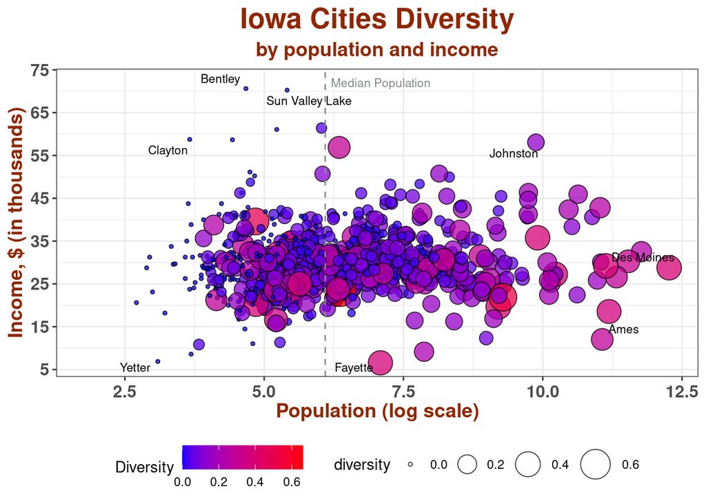

```r
div1
```

## Counties Code

```r
# county level diversity index
labs <- acs.counties$county
acs.counties$diversity <- NA
for (i in 1:length(labs)){    # subtract from 1 so low diversity = 0 & high diversity = 1
  acs.counties$diversity[i] <- 1 - sum((sum(acs.counties$pop.white[i])/acs.counties$population[i])^2
                                       , (sum(acs.counties$pop.black[i]/acs.counties$population[i]))^2
                                       , (sum(acs.counties$pop.indian[i]/acs.counties$population[i]))^2
                                       , (sum(acs.counties$pop.asian[i]/acs.counties$population[i]))^2
                                       , (sum(acs.counties$pop.hawai[i]/acs.counties$population[i]))^2
                                       , (sum(acs.counties$pop.other[i]/acs.counties$population[i]))^2
                                       , (sum(acs.counties$pop.multi[i]/acs.counties$population[i]))^2

  )
}

# county level diversity plot
rep_lab <- c("Story", "Decatur", "Dallas"
              , "Warren", "Grundy", "Adams"
              , "Polk", "Linn")
acs.counties$rep_lab <- NA
for (i in 1:nrow(acs.counties)){
  if(acs.counties$county[i] %in% rep_lab){
    acs.counties$rep_lab[i] <- acs.counties$county[i]
  }
}

diversity <- acs.counties$diversity
div2 <- ggplot(acs.counties, aes(x = log(population)
                                 , y = income
                                 , fill = diversity
                                 , size = diversity)
) +
  geom_point(color = "black"
             , shape = 21
             , stroke = 0.5
             , alpha = 0.75
  ) +
  scale_size_continuous(range = c(1, 10)
  ) +
  geom_vline(aes(xintercept = median(log(population))
  )
  , color = "azure4"
  , linetype = "dashed"
  , size = 0.5
  ) +
  annotate(geom = "text"
           , x = median(log(acs.counties$population)) - 0.5
           , y = 42500
           , color = "azure4"
           , size = 3
           , label = "Median Population"
  ) +
  scale_color_gradient2(mid = "blue"
                        , high = "red",
                        space = "Lab",
                        guide = "colourbar",
                        aesthetics = "fill"
                        , name = "Diversity") +
  labs(title = "Iowa Counties Diversity"
       , subtitle = "by population and income"
       , x = "Population (log scale)"
       , y = "Income, $ (in thousands)"
  ) +
  geom_text_repel(aes(label = rep_lab)
                  , color = "black"
                  , size = 3
                  , na.rm = TRUE
                  , point.padding = 0.5
                  , segment.color = "light grey"
  ) +
  theme_bw() +
  theme(plot.title = element_text(hjust = 0.5
                                  , face = "bold"
                                  , size = 20
                                  , color = "#912600"
  )
  , plot.subtitle = element_text(hjust = 0.5
                                 , face = "bold"
                                 , size = 14
                                 , color = "#912600"
  )
  , axis.title.x = element_text(face = "bold"
                                , color = "#912600"
                                , size = 14
  )
  , axis.text.x  = element_text(face = "bold"
                                , vjust = 0.5
                                , size = 12
  )
  , axis.title.y = element_text(face = "bold"
                                , color = "#912600"
                                , size = 14
  )
  , axis.text.y = element_text(face = "bold"
                               , vjust = 0.5
                               , size = 12
  )
  , legend.position = "bottom"
  ) +
  scale_y_continuous(breaks = seq(from = 20000
                                  , to = 45000
                                  , by = 5000
  )
  , labels = seq(from = 20
                 , to = 45
                 , by = 5
  )
  )
```

## Counties Plot

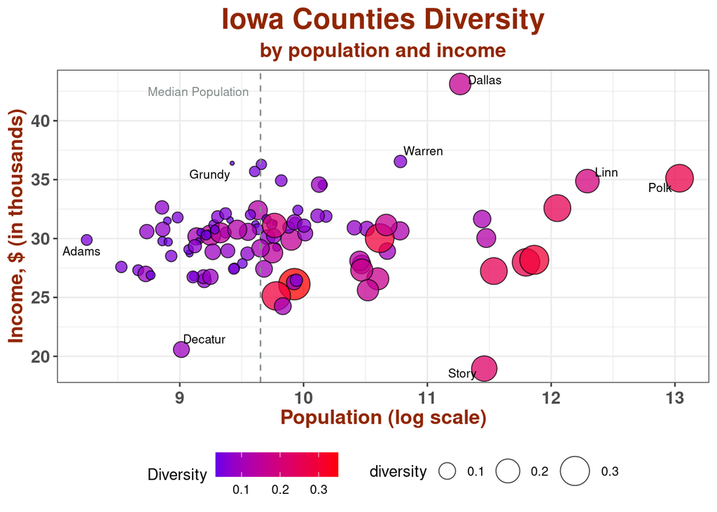

```r
div2
```

## Zipcodes Code

```r
# zipcode level diversity index
labs <- acs.zipcodes$zipcode
acs.zipcodes$diversity <- NA
for (i in 1:length(labs)){    # subtract from 1 so low diversity = 0 & high diversity = 1
  acs.zipcodes$diversity[i] <- 1 - sum((sum(acs.zipcodes$pop.white[i])/acs.zipcodes$population[i])^2
                                       , (sum(acs.zipcodes$pop.black[i]/acs.zipcodes$population[i]))^2
                                       , (sum(acs.zipcodes$pop.indian[i]/acs.zipcodes$population[i]))^2
                                       , (sum(acs.zipcodes$pop.asian[i]/acs.zipcodes$population[i]))^2
                                       , (sum(acs.zipcodes$pop.hawai[i]/acs.zipcodes$population[i]))^2
                                       , (sum(acs.zipcodes$pop.other[i]/acs.zipcodes$population[i]))^2
                                       , (sum(acs.zipcodes$pop.multi[i]/acs.zipcodes$population[i]))^2

  )
}

# zipcode level diversity plot
rep_lab <- c("50323", "50061", "50252", "51111"
             , "50319", "50127", "50011", "50012"
             , "52242", "52142", "50652", "50014"
             , "50426", "52588")
acs.zipcodes$rep_lab <- NA
for (i in 1:nrow(acs.zipcodes)){
  if(acs.zipcodes$zipcode[i] %in% rep_lab){
    acs.zipcodes$rep_lab[i] <- acs.zipcodes$zipcode[i]
  }
}
diversity <- acs.zipcodes$diversity
div3 <- ggplot(acs.zipcodes, aes(x = log(population)
                                 , y = income
                                 , fill = diversity
                                 , size = diversity)
) +
  geom_point(color = "black"
             , shape = 21
             , stroke = 0.5
             , alpha = 0.85
  ) +
  scale_size_continuous(range = c(1, 10)
  ) +
  geom_vline(aes(xintercept = median(log(population))
  )
  , color = "azure4"
  , linetype = "dashed"
  , size = 0.5
  ) +
  annotate(geom = "text"
           , x = median(log(acs.zipcodes$population)) - 0.8
           , y = 7500
           , color = "azure4"
           , size = 3
           , label = "Median Population"
  ) +
  scale_color_gradient2(mid = "blue"
                        , high = "red",
                        space = "Lab",
                        guide = "colourbar",
                        aesthetics = "fill"
                        , name = "Diversity") +
  labs(title = "Iowa Zipcodes Diversity"
       , subtitle = "by population and income"
       , x = "Population (log scale)"
       , y = "Income, $ (in thousands)"
  ) +
  geom_text_repel(aes(label = rep_lab)
                  , color = "black"
                  , size = 3
                  , na.rm = TRUE
                  , point.padding = 0.5
                  , segment.color = "light grey"
  ) +
  theme_bw() +
  theme(plot.title = element_text(hjust = 0.5
                                  , face = "bold"
                                  , size = 20
                                  , color = "#912600"
  )
  , plot.subtitle = element_text(hjust = 0.5
                                 , face = "bold"
                                 , size = 14
                                 , color = "#912600"
  )
  , axis.title.x = element_text(face = "bold"
                                , color = "#912600"
                                , size = 14
  )
  , axis.text.x  = element_text(face = "bold"
                                , vjust = 0.5
                                , size = 12
  )
  , axis.title.y = element_text(face = "bold"
                                , color = "#912600"
                                , size = 14
  )
  , axis.text.y = element_text(face = "bold"
                               , vjust = 0.5
                               , size = 12
  )
  , legend.position = "bottom"
  ) +
  scale_y_continuous(breaks = seq(from = 0
                                  , to = 80000
                                  , by = 10000
  )
  , labels = seq(from = 0
                 , to = 80
                 , by = 10
  )
  )
```

## Zipcodes Plot

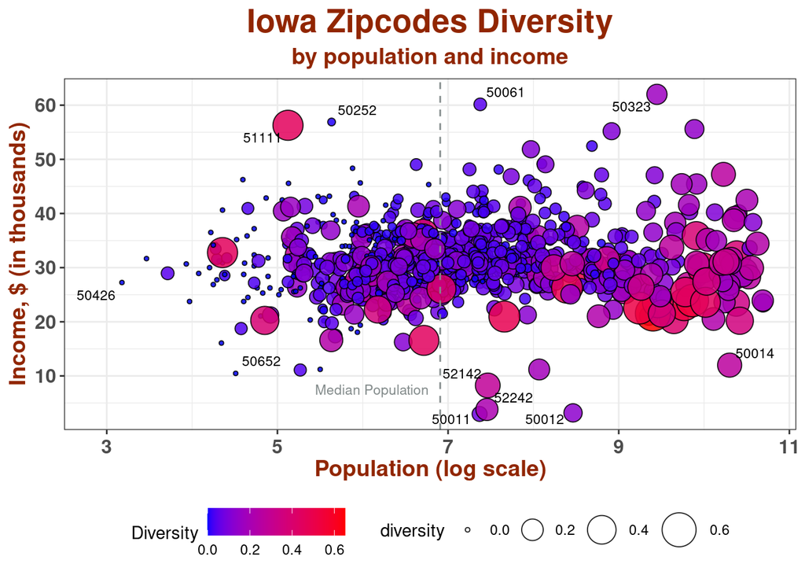

```r
div3
```

# ICD Bar Chart

## Sales Code

```r
# add geo tag
sales.cities.stats.dol$geo <- c("city")
sales.counties.stats.dol$geo <- c("county")
sales.zipcodes.stats.dol$geo <- c("zipcode")

# add sum of sales as column
# city
labs <- sales.cities.stats.dol$variable
sales.cities.stats.dol$sum <- NA
for (i in 1:length(labs)) {
  sales.cities.stats.dol$sum[i] <- sum(sales.cities[sales.cities$category == labs[i],"sale.dollars"])
}

# county
sales.counties.stats.dol$sum <- NA
for (i in 1:length(labs)) {
  sales.counties.stats.dol$sum[i] <- sum(sales.counties[sales.counties$category == labs[i],"sale.dollars"])
}

# zipcode
sales.zipcodes.stats.dol$sum <- NA
for (i in 1:length(labs)) {
  sales.zipcodes.stats.dol$sum[i] <- sum(sales.zipcodes[sales.zipcodes$category == labs[i],"sale.dollars"])
}

# bind stats dfs
agg.sales.stats.dol <- rbind(sales.cities.stats.dol
                             , sales.counties.stats.dol
                             , sales.zipcodes.stats.dol)
# plot
liq.dollar.comp <- ggplot(agg.sales.stats.dol, aes(x = geo
                                 , y = sum
                                 , fill = variable
                        )
                        ) +
                          geom_bar(stat = "identity"
                                   , position = "fill"
                          ) +
  labs(title = "Liquor Sales by Dollar"
       , subtitle = "aggregated by geo level"
       , x = "Geographic level"
       , y = "% sales/$"
  ) +theme_bw() +
  theme(plot.title = element_text(hjust = 0.5
                                  , face = "bold"
                                  , size = 20
                                  , color = "#912600"
  )
  , plot.subtitle = element_text(hjust = 0.5
                                 , face = "bold"
                                 , size = 14
                                 , color = "#912600"
  )
  , axis.title.x = element_text(face = "bold"
                                , color = "#912600"
                                , size = 14
  )
  , axis.text.x  = element_text(face = "bold"
                                , vjust = 0.5
                                , size = 12
  )
  , axis.title.y = element_text(face = "bold"
                                , color = "#912600"
                                , size = 14
  )
  , axis.text.y = element_text(face = "bold"
                               , vjust = 0.5
                               , size = 12
  )
  , legend.position = "left"
  )
```

## Sales Chart

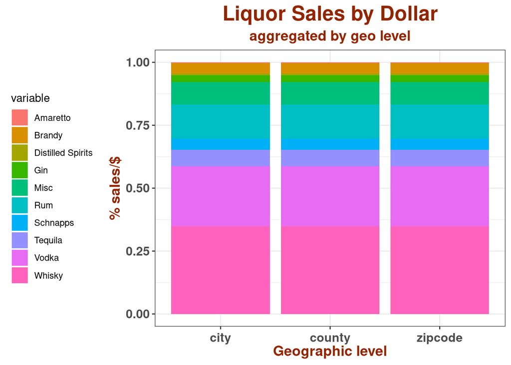

```r
liq.dollar.comp
```

## Volume Code

```r
# add geo tag
sales.cities.stats.vol$geo <- c("city")
sales.counties.stats.vol$geo <- c("county")
sales.zipcodes.stats.vol$geo <- c("zipcode")

# add sum of sales as column
# city
labs <- sales.cities.stats.vol$variable
sales.cities.stats.vol$sum <- NA
for (i in 1:length(labs)) {
  sales.cities.stats.vol$sum[i] <- sum(sales.cities[sales.cities$category == labs[i],"sale.dollars"])
}

# county
sales.counties.stats.vol$sum <- NA
for (i in 1:length(labs)) {
  sales.counties.stats.vol$sum[i] <- sum(sales.counties[sales.counties$category == labs[i],"sale.dollars"])
}

# zipcode
sales.zipcodes.stats.vol$sum <- NA
for (i in 1:length(labs)) {
  sales.zipcodes.stats.vol$sum[i] <- sum(sales.zipcodes[sales.zipcodes$category == labs[i],"sale.dollars"])
}
# bind stat dfs
agg.sales.stats.vol <- rbind(sales.cities.stats.vol
                             , sales.counties.stats.vol
                             , sales.zipcodes.stats.vol)
# plot
liq.volume.comp <- ggplot(agg.sales.stats.vol, aes(x = geo
                                                   , y = sum
                                                   , fill = variable
                          )
                          ) +
                            geom_bar(stat = "identity"
                                     , position = "fill"
                                     ) +
  labs(title = "Liquor Sales by Liter"
       , subtitle = "aggregated by geo level"
       , x = "Geographic level"
       , y = "% sale/liters"
  ) +
  theme_bw() +
  theme(plot.title = element_text(hjust = 0.5
                                  , face = "bold"
                                  , size = 20
                                  , color = "#912600"
  )
  , plot.subtitle = element_text(hjust = 0.5
                                 , face = "bold"
                                 , size = 14
                                 , color = "#912600"
  )
  , axis.title.x = element_text(face = "bold"
                                , color = "#912600"
                                , size = 14
  )
  , axis.text.x  = element_text(face = "bold"
                                , vjust = 0.5
                                , size = 12
  )
  , axis.title.y = element_text(face = "bold"
                                , color = "#912600"
                                , size = 14
  )
  , axis.text.y = element_text(face = "bold"
                               , vjust = 0.5
                               , size = 12
  )
  , legend.position = "left"
  )
```

## Volume Chart

[figure not shown]

```r
liq.volume.comp
```

# Diversity & Avg.$/L

These graphs are used to investigate the question of whether there is a connection between the level of diversity in an area and the average amount paid per liter of liquor sold. Level of diversity is on the x-axis, and the average amount spent per liter of liquor is on the y-axis, with the population represented by the size and color of the points.

Each at each geographic level there is a positive correlation between the amount of diversity in a location and the average amount spent per liter of liquor. A simple linear regression with 95% confidence bands have been added.

We already know that more concentrated population centers tend to have more diverse populations. But it may be the case that these areas with more diverse populations have larger average incomes as well, as a result of being located in urban centers. The next question will explore this possibility.

## Cities Code

```r
# cities

# liquor categories are listed separately, need to combine them
# to get avg. price per liter
cities <- unique(sales.cities$city)
agg.city.sales <- as.data.frame(as.matrix(cities
                                , nrow = length(cities)
                                , ncol = 1))
colnames(agg.city.sales) <- c("city")
agg.city.sales$sale.dollars <- NA
agg.city.sales$sale.volume <- NA

# sum of sale.dollars
for (i in 1:length(cities)){
  agg.city.sales$sale.dollars[i] <- sum(sales.cities[sales.cities$city == cities[i], "sale.dollars"])
}
# sum of sale.volume
for (i in 1:length(cities)){
  agg.city.sales$sale.volume[i] <- sum(sales.cities[sales.cities$city == cities[i], "sale.volume"])
}
# avg. price per liter
agg.city.sales$ppl <- agg.city.sales$sale.dollars/agg.city.sales$sale.volume

# make names alike
acs.cities$city <- tolower(gsub(" |'|-|_", ".", acs.cities$city))
agg.city.sales$city <- tolower(gsub(" |'|-|_", ".", agg.city.sales$city))

# merge with population
acs.sales.cities <- merge(agg.city.sales
                          , acs.cities
                          , by = c("city")
                          , all.x = FALSE, all.y = FALSE
                          )

# # the city of 'templeton', row 338 is an outlier for ppl, remove
acs.sales.cities <- acs.sales.cities[-c(338),]

# plot
ppl.city <- ggplot(acs.sales.cities, aes(x = diversity
                                 , y = ppl
                                 , fill = population
                                 , size = population)
) +
  geom_point(color = "black"
             , shape = 23
             , stroke = 0.5
             , alpha = 0.85
  ) +
  scale_size_continuous(range = c(0.5, 15)
  ) +
  geom_vline(aes(xintercept = median(diversity)
  )
  , color = "azure4"
  , linetype = "dashed"
  , size = 0.5
  ) +
  annotate(geom = "text"
           , x = median(acs.sales.cities$diversity) + 0.03
           , y = 24
           , color = "azure4"
           , size = 3
           , label = "Median\nDiversity"
  ) +
  scale_color_gradient2(mid = "orchid"
                        , high = "yellow",
                        space = "Lab",
                        guide = "colourbar",
                        aesthetics = "fill"
                        , name = "Population") +
  labs(title = "Iowa Cities"
       , subtitle = "Avg. $/L by diversity"
       , x = "Diversity"
       , y = "Liquor Sales Avg. $/l"
  ) +
  geom_smooth(method = "lm"
              , size = 0.25
              , color = "black"
              , alpha = 0.12
              ) +
  theme_bw() +
  theme(plot.title = element_text(hjust = 0.5
                                  , face = "bold"
                                  , size = 20
                                  , color = "#912600"
  )
  , plot.subtitle = element_text(hjust = 0.5
                                 , face = "bold"
                                 , size = 14
                                 , color = "#912600"
  )
  , axis.title.x = element_text(face = "bold"
                                , color = "#912600"
                                , size = 14
  )
  , axis.text.x  = element_text(face = "bold"
                                , vjust = 0.5
                                , size = 12
  )
  , axis.title.y = element_text(face = "bold"
                                , color = "#912600"
                                , size = 14
  )
  , axis.text.y = element_text(face = "bold"
                               , vjust = 0.5
                               , size = 12
  )
  , legend.position = "left"
  ) +
  scale_y_continuous(breaks = seq(from = 0
                                  , to = 55
                                  , by = 5
  )
  , labels = seq(from = 0
                 , to = 55
                 , by = 5
  )
  )
```

## Cities Plot

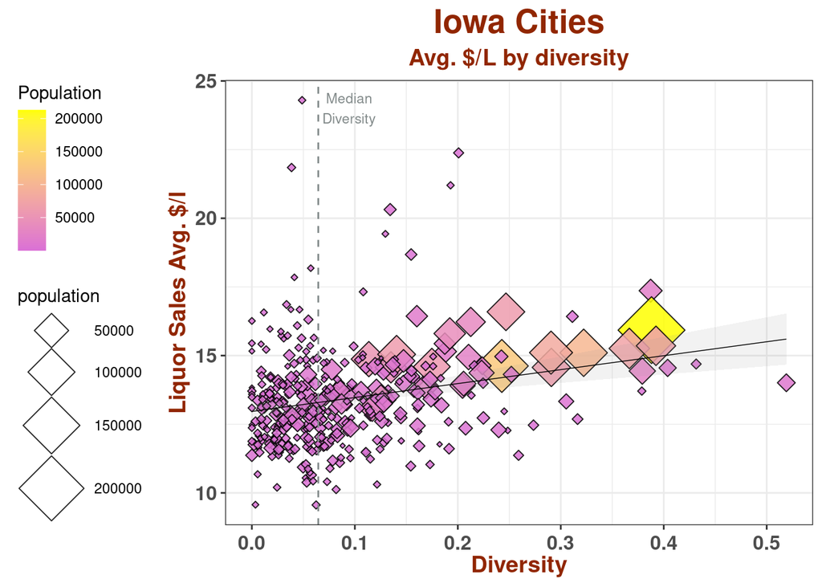

```r
ppl.city
```

## Counties Code

```r
# counties

# liquor categories are listed separately, need to combine them
# to get avg. price per liter
counties <- unique(sales.counties$county)
agg.county.sales <- as.data.frame(as.matrix(counties
                                          , nrow = length(counties)
                                          , ncol = 1))
colnames(agg.county.sales) <- c("county")
agg.county.sales$sale.dollars <- NA
agg.county.sales$sale.volume <- NA

# sum of sale.dollars
for (i in 1:length(counties)){
  agg.county.sales$sale.dollars[i] <- sum(sales.counties[sales.counties$county == counties[i], "sale.dollars"])
}
# sum of sale.volume
for (i in 1:length(counties)){
  agg.county.sales$sale.volume[i] <- sum(sales.counties[sales.counties$county == counties[i], "sale.volume"])
}
# avg. price per liter
agg.county.sales$ppl <- agg.county.sales$sale.dollars/agg.county.sales$sale.volume

# make names alike
acs.counties$county <- tolower(gsub(" |'|-|_", ".", acs.counties$county))
agg.county.sales$county <- tolower(gsub(" |'|-|_", ".", agg.county.sales$county))

# merge with population
acs.sales.counties <- merge(agg.county.sales
                          , acs.counties
                          , by = c("county")
                          , all.x = FALSE, all.y = FALSE
)

# plot
ppl.county <- ggplot(acs.sales.counties, aes(x = diversity
                                         , y = ppl
                                         , fill = population
                                         , size = population)
) +
  geom_point(color = "black"
             , shape = 23
             , stroke = 0.5
             , alpha = 0.85
  ) +
  scale_size_continuous(range = c(0.5, 15)
  ) +
  geom_vline(aes(xintercept = median(diversity)
  )
  , color = "azure4"
  , linetype = "dashed"
  , size = 0.5
  ) +
  annotate(geom = "text"
           , x = median(acs.sales.counties$diversity) + 0.025
           , y = 16
           , color = "azure4"
           , size = 3
           , label = "Median\nDiversity"
  ) +
  scale_color_gradient2(mid = "orchid"
                        , high = "yellow",
                        space = "Lab",
                        guide = "colourbar",
                        aesthetics = "fill"
                        , name = "Population") +
  labs(title = "Iowa Counties"
       , subtitle = "Avg. $/L by diversity"
       , x = "Diversity"
       , y = "Liquor Sales Avg. $/l"
  ) +
  geom_smooth(method = "lm"
              , size = 0.25
              , color = "black"
              , alpha = 0.12) +
  theme_bw() +
  theme(plot.title = element_text(hjust = 0.5
                                  , face = "bold"
                                  , size = 20
                                  , color = "#912600"
  )
  , plot.subtitle = element_text(hjust = 0.5
                                 , face = "bold"
                                 , size = 14
                                 , color = "#912600"
  )
  , axis.title.x = element_text(face = "bold"
                                , color = "#912600"
                                , size = 14
  )
  , axis.text.x  = element_text(face = "bold"
                                , vjust = 0.5
                                , size = 12
  )
  , axis.title.y = element_text(face = "bold"
                                , color = "#912600"
                                , size = 14
  )
  , axis.text.y = element_text(face = "bold"
                               , vjust = 0.5
                               , size = 12
  )
  , legend.position = "left"
  ) +
  scale_y_continuous(breaks = seq(from = 10
                                  , to = 20
                                  , by = 2
  )
  , labels = seq(from = 10
                 , to = 20
                 , by = 2
  )
  )
```

## Counties Plot

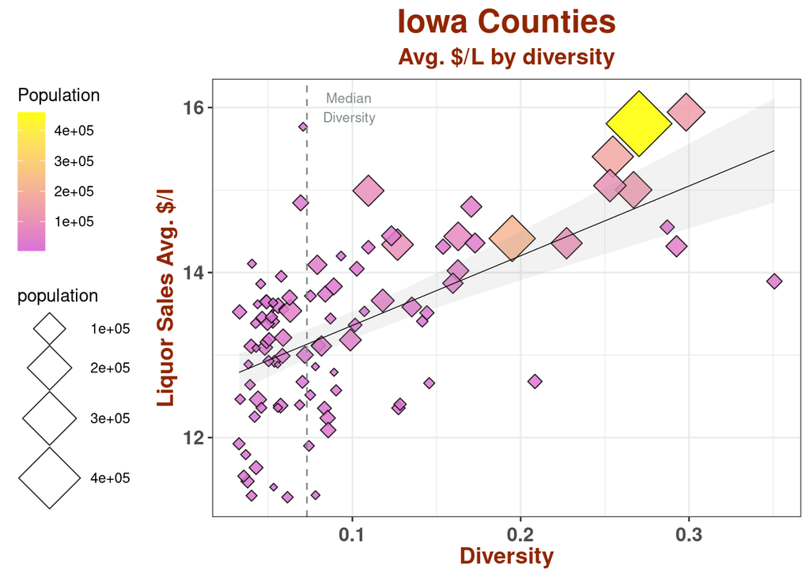

```r
ppl.county
```

## Zipcodes Code

```r
# zipcodes

# liquor categories are listed separately, need to combine them
# to get avg. price per liter
zipcodes <- unique(sales.zipcodes$zipcode)
agg.zipcode.sales <- as.data.frame(as.matrix(zipcodes
                                            , nrow = length(zipcodes)
                                            , ncol = 1))
colnames(agg.zipcode.sales) <- c("zipcode")
agg.zipcode.sales$sale.dollars <- NA
agg.zipcode.sales$sale.volume <- NA

# sum of sale.dollars
for (i in 1:length(zipcodes)){
  agg.zipcode.sales$sale.dollars[i] <- sum(sales.zipcodes[sales.zipcodes$zipcode == zipcodes[i], "sale.dollars"])
}
# sum of sale.volume
for (i in 1:length(zipcodes)){
  agg.zipcode.sales$sale.volume[i] <- sum(sales.zipcodes[sales.zipcodes$zipcode == zipcodes[i], "sale.volume"])
}
# avg. price per liter
agg.zipcode.sales$ppl <- agg.zipcode.sales$sale.dollars/agg.zipcode.sales$sale.volume

# merge with population
acs.sales.zipcodes <- merge(agg.zipcode.sales
                            , acs.zipcodes
                            , by = c("zipcode")
                            , all.x = FALSE, all.y = FALSE
)

# # the zipcode 51463, row 264 is an outlier for ppl, remove
acs.sales.zipcodes <- acs.sales.zipcodes[-c(264),]

# plot
ppl.zipcode <- ggplot(acs.sales.zipcodes, aes(x = diversity
                                             , y = ppl
                                             , fill = population
                                             , size = population)
) +
  geom_point(color = "black"
             , shape = 23
             , stroke = 0.5
             , alpha = 0.85
  ) +
  scale_size_continuous(range = c(0.5, 10)
  ) +
  geom_vline(aes(xintercept = median(diversity)
  )
  , color = "azure4"
  , linetype = "dashed"
  , size = 0.5
  ) +
  annotate(geom = "text"
           , x = median(acs.sales.counties$diversity) - 0.06
           , y = 24
           , color = "azure4"
           , size = 3
           , label = "Median\nDiversity"
  ) +
  scale_color_gradient2(mid = "orchid"
                        , high = "yellow",
                        space = "Lab",
                        guide = "colourbar",
                        aesthetics = "fill"
                        , name = "Population") +
  labs(title = "Iowa Zipcodes"
       , subtitle = "Avg. $/L by diversity"
       , x = "Diversity"
       , y = "Liquor Sales Avg. $/l"
  ) +
  geom_smooth(method = "lm"
              , size = 0.25
              , color = "black"
              , alpha = 0.12
              ) +
  theme_bw() +
  theme(plot.title = element_text(hjust = 0.5
                                  , face = "bold"
                                  , size = 20
                                  , color = "#912600"
  )
  , plot.subtitle = element_text(hjust = 0.5
                                 , face = "bold"
                                 , size = 14
                                 , color = "#912600"
  )
  , axis.title.x = element_text(face = "bold"
                                , color = "#912600"
                                , size = 14
  )
  , axis.text.x  = element_text(face = "bold"
                                , vjust = 0.5
                                , size = 12
  )
  , axis.title.y = element_text(face = "bold"
                                , color = "#912600"
                                , size = 14
  )
  , axis.text.y = element_text(face = "bold"
                               , vjust = 0.5
                               , size = 12
  )
  , legend.position = "left"
  ) +
  scale_y_continuous(breaks = seq(from = 0
                                  , to = 55
                                  , by = 5
  )
  , labels = seq(from = 0
                 , to = 55
                 , by = 5
  )
  )
```

## Zipcodes Plot

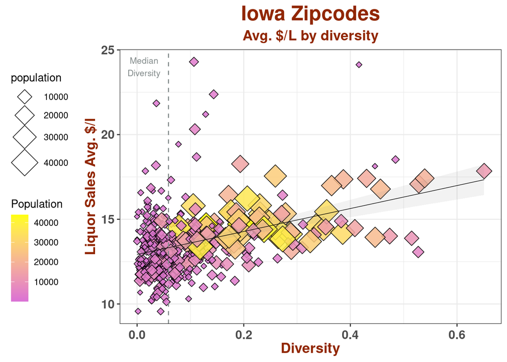

```r
ppl.zipcode
```

# Diversity, Avg.$/L & Income

These next charts present average liquor sales, defined as the total sales in dollars divided by the total sale in liters, as a function of median income. Diversity is represented by the size and color of the points.

On the city and zipcode level it can be seen that the more diverse locations are generally in the lower spectrum of median income. This shows that even though there is a tendency for locations with higher diversity to have a higher amount spent per liter of liquor, generally speaking the most diverse locations are also in the lower half of income spectrum.

## Cities Code

```r
# the city of 'templeton', row 338 is an outlier for ppl, remove
acs.sales.cities <- acs.sales.cities[-c(338),]


# plot - no outlier
inc.city <- ggplot(acs.sales.cities, aes(x = income
                                                      , y = ppl
                                                      , fill = diversity
                                                      , size = diversity)
) +
  geom_point(color = "black"
             , shape = 21
             , stroke = 0.5
             , alpha = 0.85
  ) +
  scale_size_continuous(range = c(0.5, 10)
  ) +
  geom_vline(aes(xintercept = median(income)
                )
            , color = "azure4"
            , linetype = "dashed"
            , size = 0.5
            ) +
  geom_hline(aes(yintercept = median(ppl)
                 )
            , color = "azure4"
            , linetype = "dashed"
            , size = 0.5
             ) +
  scale_color_gradient2(mid = "blue"
                        , high = "red",
                        space = "Lab",
                        guide = "colourbar",
                        aesthetics = "fill"
                        , name = "Diversity") +
  labs(title = "Iowa Cities"
       , subtitle = "Avg. $/L by income"
       , x = "Income (thousands)"
       , y = "Liquor Sales Avg. $/l"
  ) +
  theme_bw() +
  theme(plot.title = element_text(hjust = 0.5
                                  , face = "bold"
                                  , size = 20
                                  , color = "#912600"
  )
  , plot.subtitle = element_text(hjust = 0.5
                                 , face = "bold"
                                 , size = 14
                                 , color = "#912600"
  )
  , axis.title.x = element_text(face = "bold"
                                , color = "#912600"
                                , size = 14
  )
  , axis.text.x  = element_text(face = "bold"
                                , vjust = 0.5
                                , size = 12
  )
  , axis.title.y = element_text(face = "bold"
                                , color = "#912600"
                                , size = 14
  )
  , axis.text.y = element_text(face = "bold"
                               , vjust = 0.5
                               , size = 12
  )
  , legend.position = "bottom"
  ) +
  scale_y_continuous(breaks = seq(from = 0
                                  , to = 25
                                  , by = 5
  )
  , labels = seq(from = 0
                 , to = 25
                 , by = 5
  )) +
  scale_x_continuous(breaks = seq(from = 0
                                  , to = 65000
                                  , by = 10000)

  , labels = seq(from = 0
                 , to = 65
                 , by  = 10)
  )
```

## Cities Plot

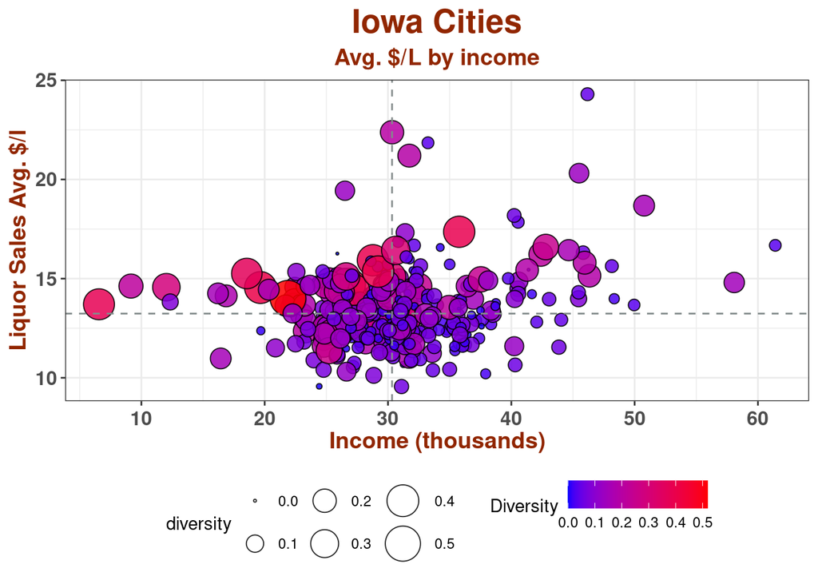

```r
inc.city
```

## Counties Code

```r
# county

# plot
inc.county <- ggplot(acs.sales.counties, aes(x = income
                                             , y = ppl
                                             , fill = diversity
                                             , size = diversity)
) +
  geom_point(color = "black"
             , shape = 21
             , stroke = 0.5
             , alpha = 0.85
  ) +
  scale_size_continuous(range = c(0.5, 10)
  ) +
  geom_vline(aes(xintercept = median(income)
                )
            , color = "azure4"
            , linetype = "dashed"
            , size = 0.5
            ) +
  geom_hline(aes(yintercept = median(ppl)
                 )
            , color = "azure4"
            , linetype = "dashed"
            , size = 0.5
             ) +
  scale_color_gradient2(mid = "blue"
                        , high = "red",
                        space = "Lab",
                        guide = "colourbar",
                        aesthetics = "fill"
                        , name = "Diversity") +
  labs(title = "Iowa Counties"
       , subtitle = "Avg. $/L by income"
       , x = "Income (thousands)"
       , y = "Liquor Sales Avg. $/l"
  ) +
  theme_bw() +
  theme(plot.title = element_text(hjust = 0.5
                                  , face = "bold"
                                  , size = 20
                                  , color = "#912600"
  )
  , plot.subtitle = element_text(hjust = 0.5
                                 , face = "bold"
                                 , size = 14
                                 , color = "#912600"
  )
  , axis.title.x = element_text(face = "bold"
                                , color = "#912600"
                                , size = 14
  )
  , axis.text.x  = element_text(face = "bold"
                                , vjust = 0.5
                                , size = 12
  )
  , axis.title.y = element_text(face = "bold"
                                , color = "#912600"
                                , size = 14
  )
  , axis.text.y = element_text(face = "bold"
                               , vjust = 0.5
                               , size = 12
  )
  , legend.position = "bottom"
  ) +
  scale_y_continuous(breaks = seq(from = 10
                                  , to = 20
                                  , by = 2
  )
  , labels = seq(from = 10
                 , to = 20
                 , by = 2
  )) +
    scale_x_continuous(breaks = seq(from = 15000
                                    , to = 45000
                                    , by = 5000)
                       , labels = seq(from = 15
                                      , to = 45
                                      , by = 5)
                       )
```

## Counties Plot

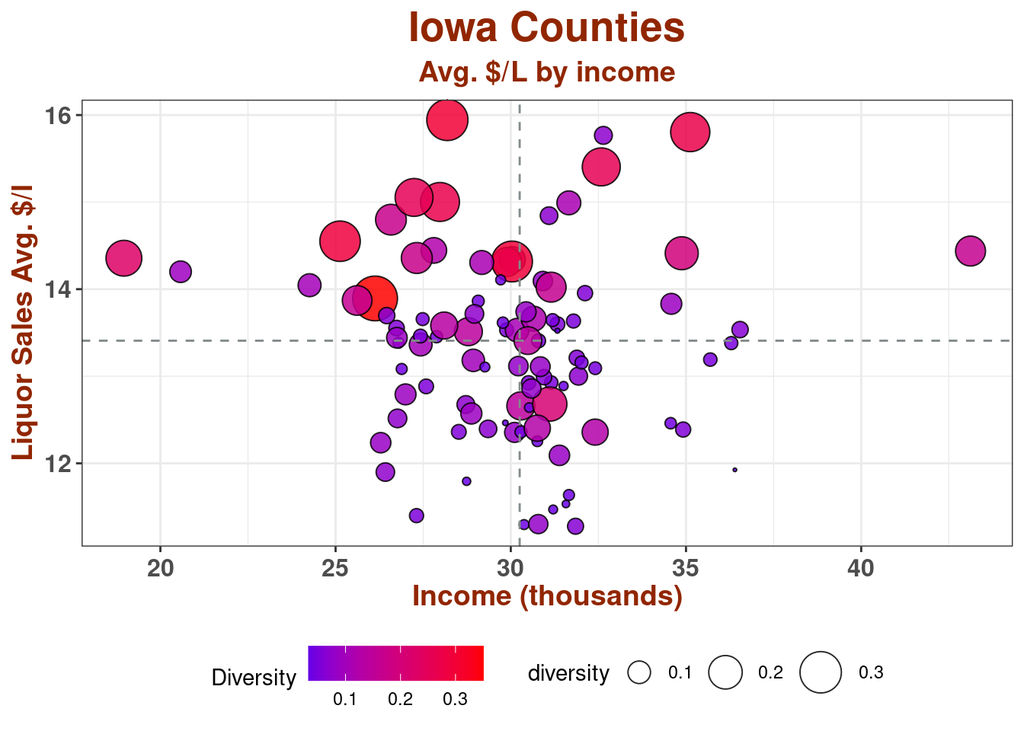

```r
inc.county
```

## Zipcodes Code

```r
# zipcode

# remove outlier
# the city of 'templeton', row 264 is an outlier for ppl, remove
acs.sales.zipcodes <- acs.sales.zipcodes[-c(264),]

# plot
inc.zipcode <- ggplot(acs.sales.zipcodes, aes(x = income
                                              , y = ppl
                                              , fill = diversity
                                              , size = diversity)
) +
  geom_point(color = "black"
             , shape = 21
             , stroke = 0.5
             , alpha = 0.85
  ) +
  scale_size_continuous(range = c(0.5, 10)
  ) +
  geom_vline(aes(xintercept = median(income)
                )
            , color = "azure4"
            , linetype = "dashed"
            , size = 0.5
            ) +
  geom_hline(aes(yintercept = median(ppl)
                 )
            , color = "azure4"
            , linetype = "dashed"
            , size = 0.5
             ) +
  scale_color_gradient2(mid = "blue"
                        , high = "red",
                        space = "Lab",
                        guide = "colourbar",
                        aesthetics = "fill"
                        , name = "Diversity") +
  labs(title = "Iowa Zipcodes"
       , subtitle = "Avg. $/l by income"
       , x = "Income (thousands)"
       , y = "Liquor Sales Avg. $/l"
  ) +
  theme_bw() +
  theme(plot.title = element_text(hjust = 0.5
                                  , face = "bold"
                                  , size = 20
                                  , color = "#912600"
  )
  , plot.subtitle = element_text(hjust = 0.5
                                 , face = "bold"
                                 , size = 14
                                 , color = "#912600"
  )
  , axis.title.x = element_text(face = "bold"
                                , color = "#912600"
                                , size = 14
  )
  , axis.text.x  = element_text(face = "bold"
                                , vjust = 0.5
                                , size = 12
  )
  , axis.title.y = element_text(face = "bold"
                                , color = "#912600"
                                , size = 14
  )
  , axis.text.y = element_text(face = "bold"
                               , vjust = 0.5
                               , size = 12
  )
  , legend.position = "bottom"
  ) +
  scale_y_continuous(breaks = seq(from = 0
                                  , to = 55
                                  , by = 5
  )
  , labels = seq(from = 0
                 , to = 55
                 , by = 5
  )) +
    scale_x_continuous(breaks = seq(from = 0
                                    , to = 75000
                                    , by = 10000)
                       , labels = seq(from = 0
                                      , to = 75
                                      , by = 10)
    )
```

## Zipcodes Plot

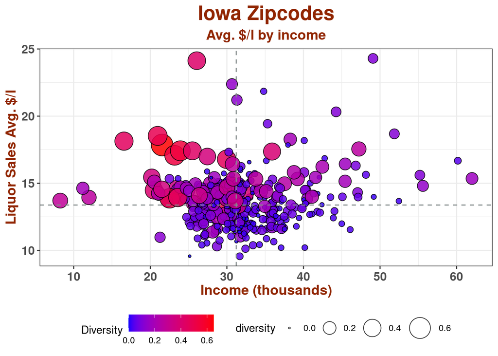

```r
inc.zipcode
```